# Water Quality Report for Pine Creek (PIN22.72)

**Monitoring period:** November 04, 2025 through September 27, 2026  
**Data current through:** 2026-09-27  
**Report generated:** 2026-10-02

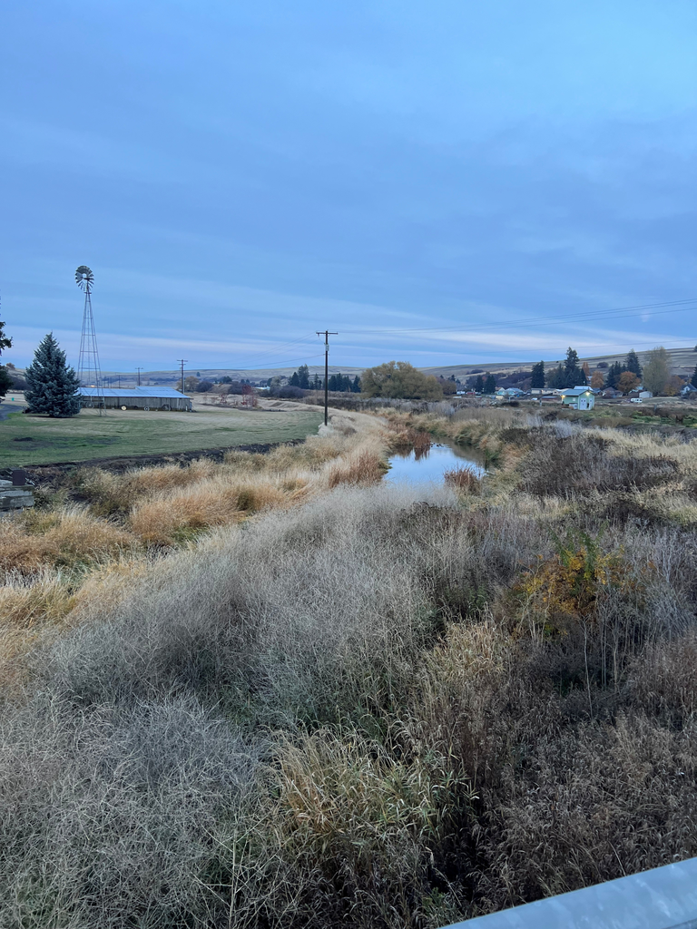

Monitoring Site

## About this report

This report summarizes community monitoring results for this location. Results describe conditions observed on the sampling dates and may not represent conditions at other times. State water-quality criteria are provided only as context. A formal compliance determination requires the correct designated use, required calculation period, representative sampling, and other regulatory considerations.

## Data summary

| Parameter | Samples | First date | Last date | Minimum | Mean | Maximum |
| --- | --- | --- | --- | --- | --- | --- |
| Air Temperature Average (ºC) | 10 | 2025-11-04 | 2026-09-27 | 0 | 14.55 | 29.0 |
| Dissolved Oxygen (mg/L) | 10 | 2025-11-04 | 2026-09-27 | 8 | 10.50 | 12.0 |
| pH | 9 | 2025-11-04 | 2026-09-27 | 7 | 7.64 | 8.5 |
| Water Temperature Average (ºC) | 10 | 2025-11-04 | 2026-09-27 | 0 | 11.30 | 23.0 |
| Turbidity (NTU) | 8 | 2025-11-04 | 2026-09-27 | 10 | 20.06 | 49.0 |
| Nitrate-N (mg/L) | 10 | 2025-11-04 | 2026-09-27 | 0 | 4.80 | 15.0 |
| Bank Stability | 1 | 2026-08-28 | 2026-08-28 | 5 | 5.00 | 5.0 |
| Vegetation Protection (%) | 1 | 2026-08-28 | 2026-08-28 | 1 | 1.00 | 1.0 |

## State water-quality criteria reference

These are general screening references for parameters in this report. These values help interpret monitoring results but should not be used to determine whether the site meets Washington water-quality standards.A formal assessment requires confirming which standards apply to the specific stream reach and using the evaluation methods required by the Washington State Department of Ecology.

| Parameter | Reference criterion | Important limitation | Source |
| --- | --- | --- | --- |
| Dissolved Oxygen (mg/L) | 10 mg/L or 90% saturation for the salmonid spawning/rearing use category | The applicable value depends on the designated aquatic life use and is evaluated as a one-day minimum. | WAC 173-201A-200(1)(d) |
| pH | 6.5 to 8.5 pH units | Allowable human-caused variation also applies and depends on the designated aquatic life use. | WAC 173-201A-200(1)(g) |
| Water Temperature Average (ºC) | 17.5 ºC for the salmonid spawning/rearing use category | The criterion is a 7-day average of daily maximum temperatures and cannot be evaluated using a simple field average. | WAC 173-201A-200(1)(c) |
| Turbidity (NTU) | 5 NTU above background when background is 50 NTU or less; otherwise no more than a 10% increase | The applicable increase depends on designated aquatic life use and requires a representative background measurement. | WAC 173-201A-200(1)(e) |

## Parameter results

### Air and water temperature

Air and water temperatures measured at this monitoring site.

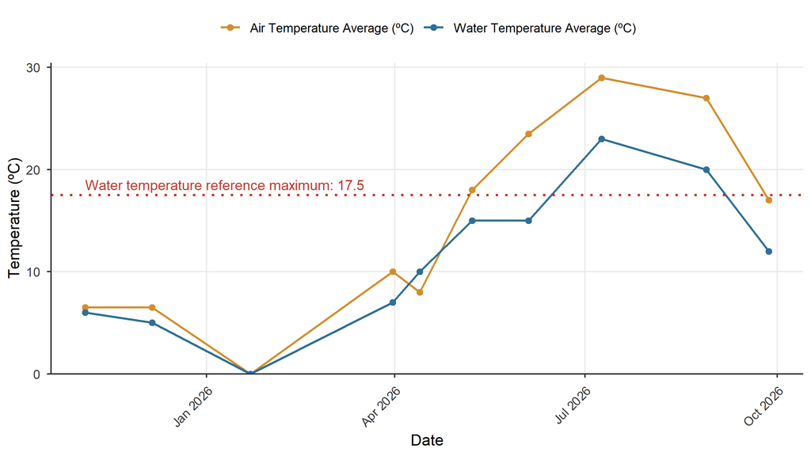

### Dissolved Oxygen (mg/L)

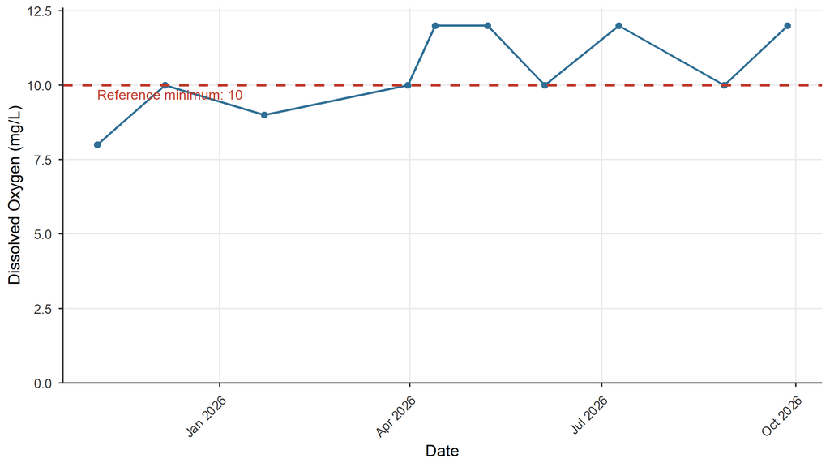

### pH

pH is a measure of how acidic or alkaline the water is. Washington’s freshwater aquatic life criteria generally require pH to remain between 6.5 and 8.5, with limits on human-caused variation.

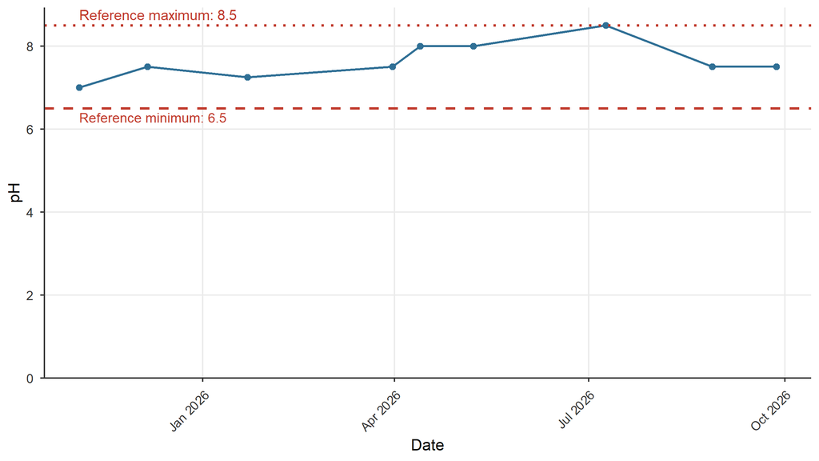

### Turbidity (NTU)

Turbidity in nephelometric turbidity units. Washington’s freshwater turbidity criterion is based on the increase above background and depends on the designated aquatic life use.

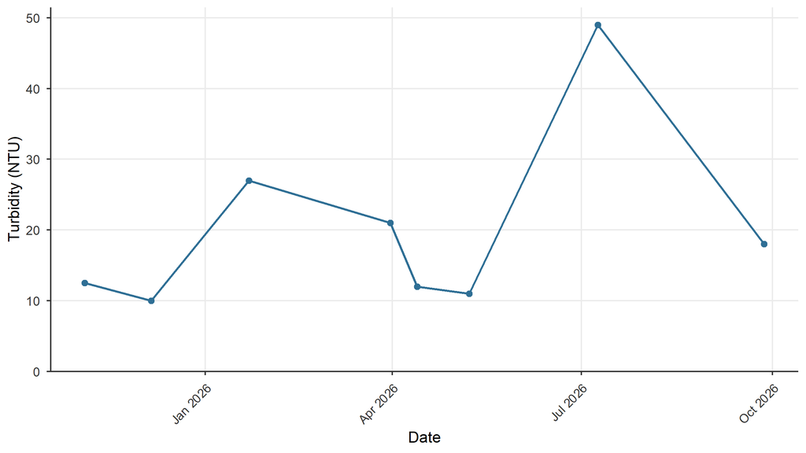

### Nitrate-N (mg/L)

Nitrate is a form of nitrogen that is easily transported by water. It occurs naturally, but excessive nitrate can contribute to increased aquatic plant and algae growth. Nitrate can come from soil organic matter, animal waste, plant decomposition, sewage, and fertilizer associated with runoff.

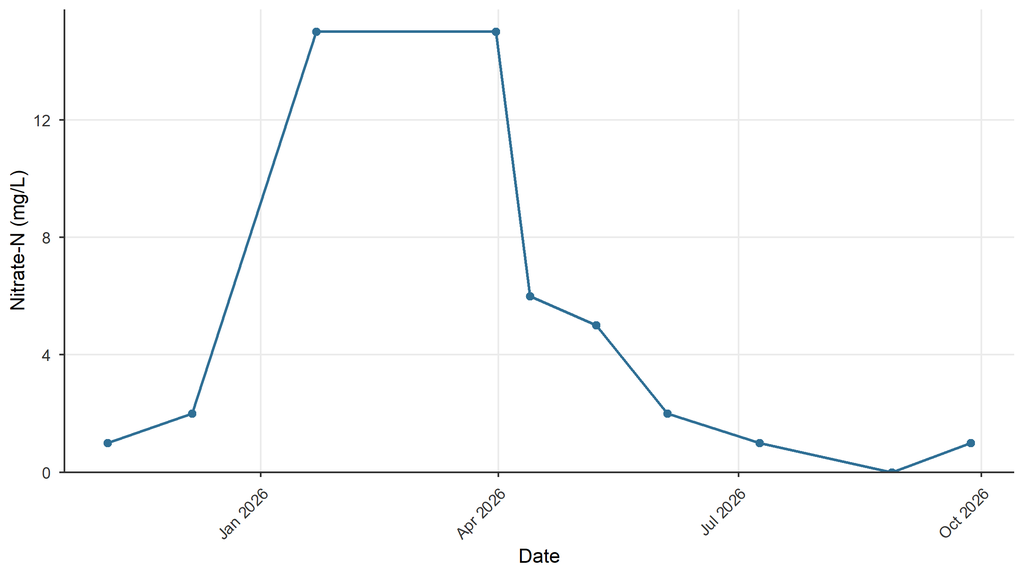

### Bank Stability

The recorded bank stability assessment, describing the ability of a streambank, including its soils and vegetation, to resist erosion from water flows and gravity.

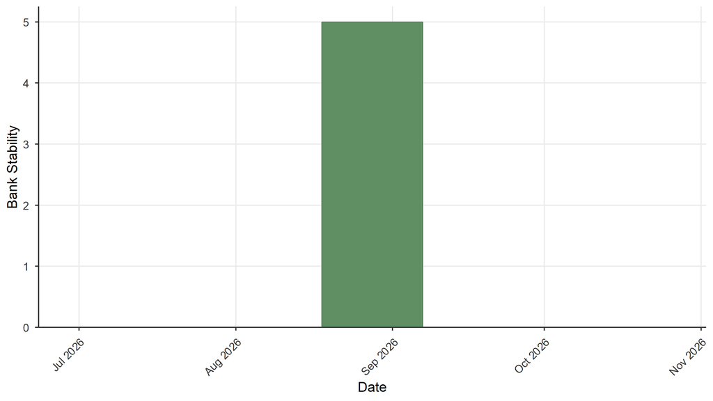

### Vegetation Protection (%)

The percentage of the streambank protected by vegetation. Plant roots help hold soil in place and provide shade and habitat along the stream.

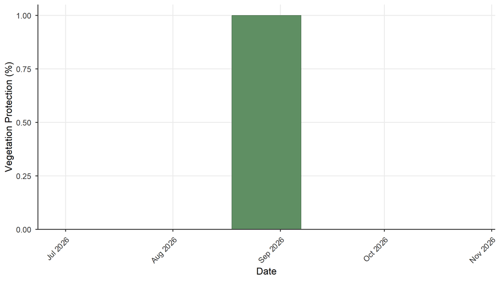

## Data note

This report was generated by the Palouse Conservation District using the Confluence Crew data.